# R Notebook

# Se quiere presentar la grafica para frecuecia para el numero de hijos

El grafico de frecuencias para una variable discreta y continua es la misma

##___________________________________________________________________________________ ## Ejercicio: Analice si existe asociaci?n entre el historial de compra y el g?nero ##___________________________________________________________________________________

```r
#------------------------------------------------------------------#
#  d) Representaci?n de Datos Cuantitativos Discretos              #
#------------------------------------------------------------------#
# Tabla de Frecuencias
ni<-table(DMark$Hijos)
fi<-prop.table(table(DMark$Hijos))
pi<-prop.table(table(DMark$Hijos))*100
hijos.tabla<-t(rbind(ni,fi,pi))
hijos.tabla
```

```
   ni    fi   pi
0 462 0.462 46.2
1 267 0.267 26.7
2 146 0.146 14.6
3 125 0.125 12.5
```

Como es una variable discreta se debe usar una grafica de Varas. Conceptualmente NO ES RECOMENDABLE una grafica de BARRAS.

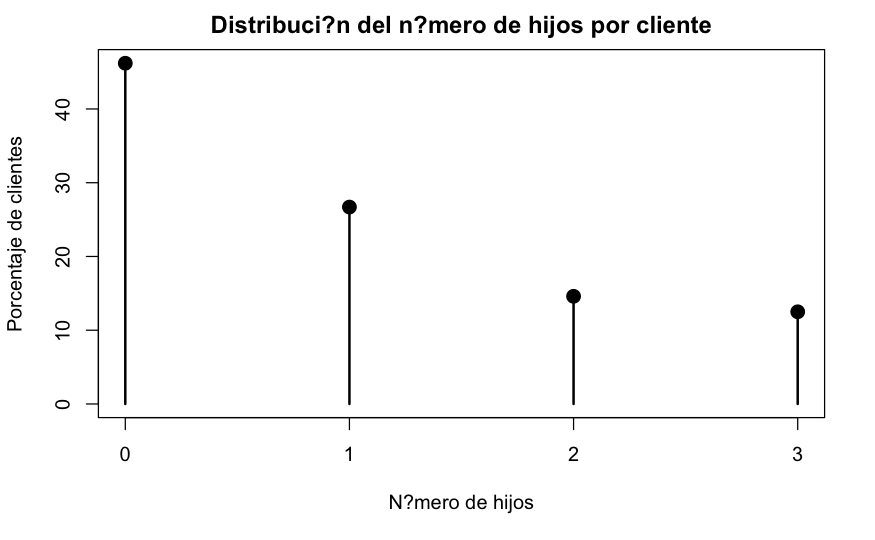

```r
# Visualizaci?n de la Distribuci?n de la Variable
# ------------------------------------------------
#Gr?fico de Varas
plot(pi, type="h", lwd=2,
     xlab="N?mero de hijos",
     ylab="Porcentaje de clientes",
     main="Distribuci?n del n?mero de hijos por cliente")
points(x =as.numeric(row.names(pi)),
       y =as.numeric(pi),
       pch=19,cex=1.5)
```

Para diferenciar las frecuencias se pone un punto al final. Lo mas frecuente es tener clientes sin hijos

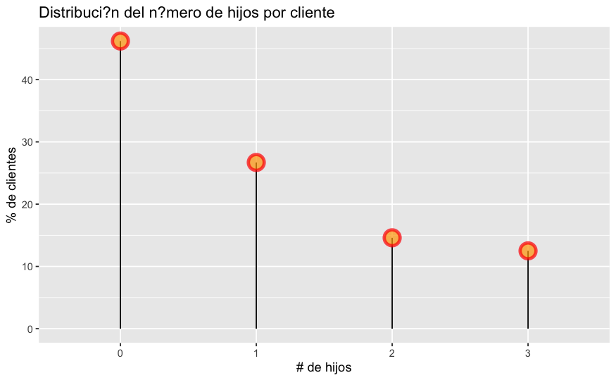

```r
#Usando ggplot2
df <- as.data.frame(pi)
ggplot(df, aes(x=Var1, y=Freq)) +
  geom_segment( aes(x=Var1, xend=Var1, y=0, yend=Freq)) +
  geom_point( size=5, color="red", fill=alpha("orange", 0.3), alpha=0.7, shape=21, stroke=2) +
  labs(x = "# de hijos", y = "% de clientes", title = "Distribuci?n del n?mero de hijos por cliente")
```

## Se busca el patron, no los valores.

Con una variable cuantitativa continua

Un motivo empirico, la razon es resumir la tabla Por un tema conceptual, porque son variables continuas, por eso se coloca en intervalos

| La cantidad de intervalos, el tamaño de cada intervalos, y como tomo los limites |
| --- |
| Se usa la regla de Sturges, pero no es eficiente, pero es simple. |
| En la regla de Sturges no considera la variabilidad de los datos. |
| Cuando tienes valores extremos no es recomendable la regla de Sturges. |
| Cuando se aplica Sturges con valores extremos, se tendra intervalos sin valores |

```r
#------------------------------------------------------------------#
#  e) Representaci?n de Datos Cuantitativos Continuos              #
#------------------------------------------------------------------#

# Tabla de Frecuencias (usando la regla de Sturges)
factorx <- factor(cut(DMark$Monto, breaks=nclass.Sturges(DMark$Monto),right=TRUE))
xout <- as.data.frame(table(factorx))
colnames(xout)<-c("Monto","ni")
xout <- transform(xout,
                  fi=prop.table(ni),
                  pi=prop.table(ni)*100,
                  Ni = cumsum(ni),
                  Fi = cumsum(prop.table(ni)),
                  Pi = cumsum(prop.table(ni))*100
)
xout
```

| Monto | ni | fi | pi | Ni | Fi | Pi |
| --- | --- | --- | --- | --- | --- | --- |
| (31.8,600] | 322 | 0.322 | 32.2 | 322 | 0.322 | 32.2 |
| (600,1.16e+03] | 255 | 0.255 | 25.5 | 577 | 0.577 | 57.7 |
| (1.16e+03,1.72e+03] | 186 | 0.186 | 18.6 | 763 | 0.763 | 76.3 |
| (1.72e+03,2.28e+03] | 101 | 0.101 | 10.1 | 864 | 0.864 | 86.4 |
| (2.28e+03,2.85e+03] | 74 | 0.074 | 7.4 | 938 | 0.938 | 93.8 |
| (2.85e+03,3.41e+03] | 34 | 0.034 | 3.4 | 972 | 0.972 | 97.2 |
| (3.41e+03,3.97e+03] | 14 | 0.014 | 1.4 | 986 | 0.986 | 98.6 |
| (3.97e+03,4.53e+03] | 4 | 0.004 | 0.4 | 990 | 0.990 | 99.0 |
| (4.53e+03,5.09e+03] | 3 | 0.003 | 0.3 | 993 | 0.993 | 99.3 |
| (5.09e+03,5.66e+03] | 4 | 0.004 | 0.4 | 997 | 0.997 | 99.7 |

[output cut: 1 more lines]

Explicacion :

El volumene de compra son relativamente bajos. mayormente compran hasta intevarlos de 1160 dolares

Profesor Felipe Mendiburo. libreria bricolae

# Obtener la tabla de una librer?a

```r
library(agricolae)
(table.freq(hist(DMark$Monto,breaks = "Sturges",plot=FALSE))) #Regla Sturges
```

| Lower | Upper | Main | Frequency | Percentage | CF | CPF |
| --- | --- | --- | --- | --- | --- | --- |
| 0 | 500 | 250 | 259 | 25.9 | 259 | 25.9 |
| 500 | 1000 | 750 | 260 | 26.0 | 519 | 51.9 |
| 1000 | 1500 | 1250 | 168 | 16.8 | 687 | 68.7 |
| 1500 | 2000 | 1750 | 133 | 13.3 | 820 | 82.0 |
| 2000 | 2500 | 2250 | 72 | 7.2 | 892 | 89.2 |
| 2500 | 3000 | 2750 | 52 | 5.2 | 944 | 94.4 |
| 3000 | 3500 | 3250 | 30 | 3.0 | 974 | 97.4 |
| 3500 | 4000 | 3750 | 13 | 1.3 | 987 | 98.7 |
| 4000 | 4500 | 4250 | 3 | 0.3 | 990 | 99.0 |
| 4500 | 5000 | 4750 | 3 | 0.3 | 993 | 99.3 |

[output cut: 3 more lines]

La mitad de los clientes tienen hasta 1000 dolares

```r
(table.freq(graph.freq(DMark$Monto,plot=FALSE)))   #Regla Sturges (Agricolae)
```

| Lower | Upper | Main | Frequency | Percentage | CF | CPF |
| --- | --- | --- | --- | --- | --- | --- |
| 30 | 593 | 311.5 | 322 | 32.2 | 322 | 32.2 |
| 593 | 1156 | 874.5 | 252 | 25.2 | 574 | 57.4 |
| 1156 | 1719 | 1437.5 | 187 | 18.7 | 761 | 76.1 |
| 1719 | 2282 | 2000.5 | 103 | 10.3 | 864 | 86.4 |
| 2282 | 2845 | 2563.5 | 74 | 7.4 | 938 | 93.8 |
| 2845 | 3408 | 3126.5 | 34 | 3.4 | 972 | 97.2 |
| 3408 | 3971 | 3689.5 | 14 | 1.4 | 986 | 98.6 |
| 3971 | 4534 | 4252.5 | 4 | 0.4 | 990 | 99.0 |
| 4534 | 5097 | 4815.5 | 3 | 0.3 | 993 | 99.3 |
| 5097 | 5660 | 5378.5 | 4 | 0.4 | 997 | 99.7 |

[output cut: 1 more lines]

Se pueden usar los histogramas, poligonos y graficas de densidad

Las 3 graficas me permiten ver la funcion de densidad

La ojiva sirve para mostrar la fucion acumulativa.

Cuando tienes variables, diagrama de cajas es para identificar los outlier , ver los quartiles ( es decir para ver dispersion). La medianda me sirve para ver alguna posible asimetria.

# Mostrar el histograma

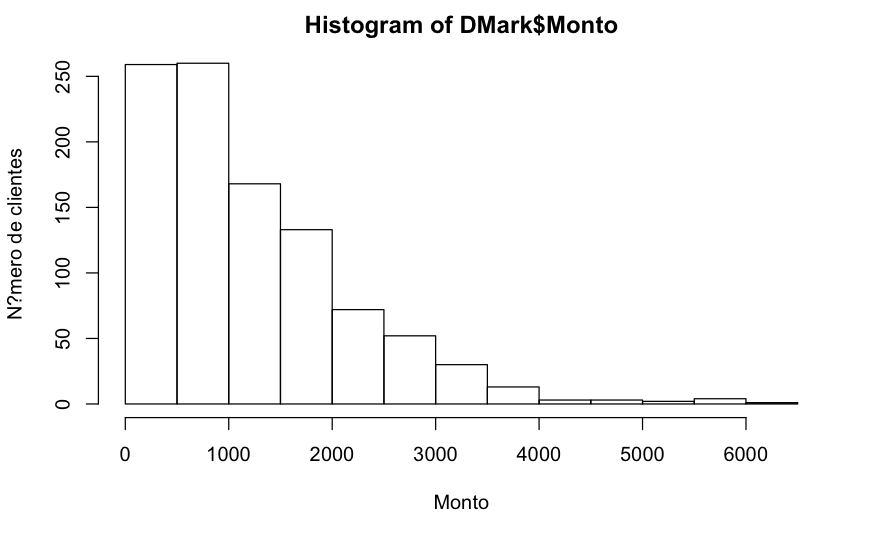

```r
# Visualizaci?n de la Distribuci?n de la Variable
# ------------------------------------------------
# Histograma y pol?gono de frecuencia
h1<-hist(DMark$Monto,breaks = "Sturges",
         xlab="Monto",
         ylab="N?mero de clientes")
```

La forma de la distribucion de las frecuencias de los clientes tiene una asiemtrica positiva.Hay algunos clientes que tienen gastos inusualmente elevados comparados con el resto

Un modelo estadistico se caracteriza porque tiene un modelo probabilistico

En el modelo de regresion lineal, las distribucion del histograma deberia ser normal.

1ra .alternativa Modelos que no usan variables parametricas: Arbol de regresion Pero no puedo inferir

2da. alternativa Transformar las variables

3ra. Usar un modelo lineal generalizado Se puede usar una distribucion gamma o normal inversa No se puede usar poisson porque se usa para variables discretas

El poligono se construye con las marcas de clases

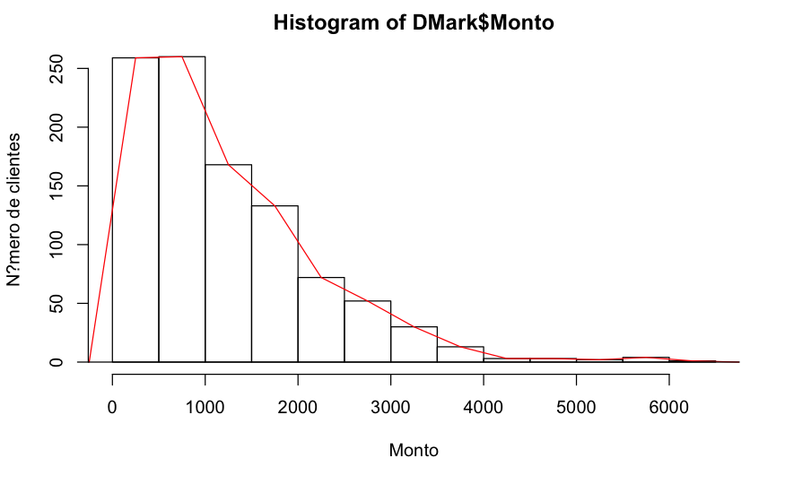

```r
# Histograma y pol?gono de frecuencia
h1<-hist(DMark$Monto,breaks = "Sturges",
         xlab="Monto",
         ylab="N?mero de clientes")
polygon.freq(h1,frequency=1,col="red")
```

```r
# Pol?gono de Frecuencias (solo)
h1<-hist(DMark$Monto,border=FALSE)
polygon.freq(h1,frequency=1,col="red")
```

[output not shown]

Las graficas de densidad se debe controlar el Bandwith , porque se puede ir en extremo

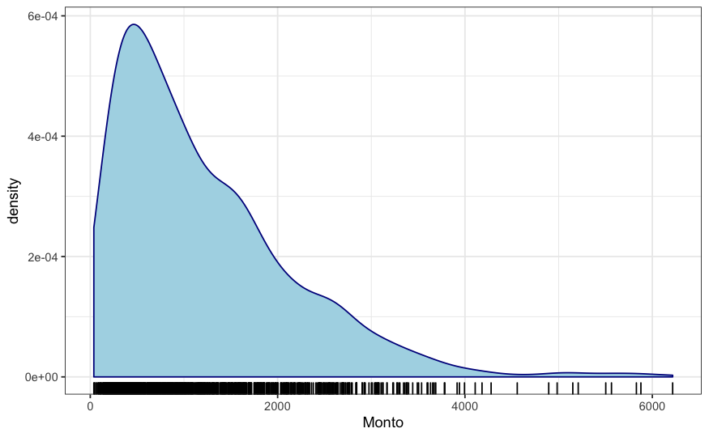

```r
# Usando ggplot2
ggplot(data = DMark, aes(x = Monto),fill = Monto) +
  geom_density(color="darkblue", fill="lightblue") +
  geom_rug() +
  theme_bw()
```

Cuando tengo valor muy negro se observa que los datos estan muy juntos, en cambio se observa que cuando hay pocos datos sale el color blanco.

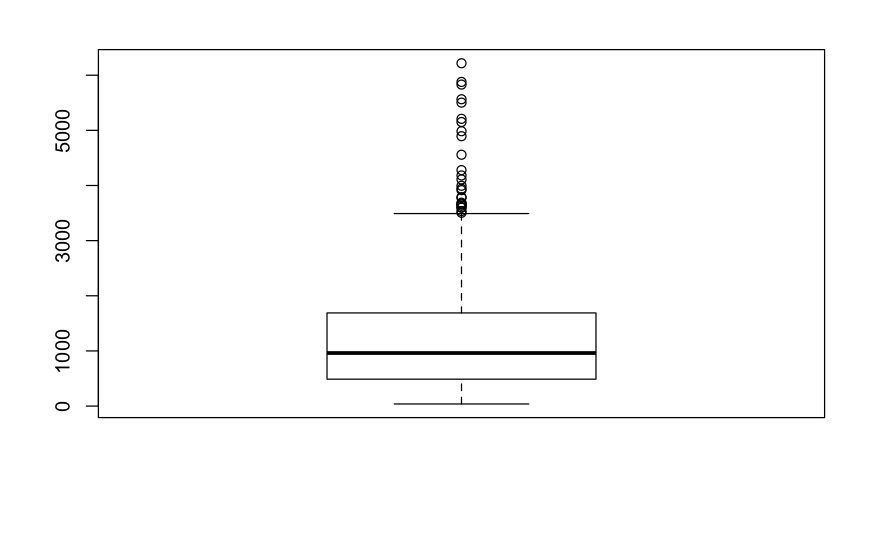

```r
#Boxplots
boxplot(DMark$Monto)
```

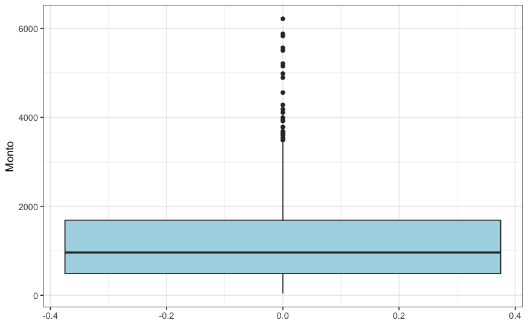

```r
# Usando ggplot2
ggplot(data = DMark, aes(y = Monto)) +
  geom_boxplot(fill="lightblue")+
  theme_bw()
```

# II .- RESUMIR

No todos los estadisticos son estimadores

Si me parametros es la media poblaciones, uso la media muestral

En el caso de intervalo de confianza : El limite inferior y superior son estadisticos, es un estadistico porque se obtiene desde la muestra aleatoria

Si el modelo parametrico, existe una cantidad finita de parametros. Si tengo una modelo normal ( distribucion normal ), solo necesito 2 parametros : media y varianza

La media es un parametro de tendencia central , y traslada de un lado a otro La varianza . hace que la distribucion tenga mayor o menor dispersion.

Que modelo es mejor, va a depender de como lo vayas a usar

Tipo de Medidas Estadisticas :

- Medida de Tipo de medida central : * Media ( centro de gravedad) : ** MAS: Media Aritmetica Simple, ** MAP: Media Aritmetica Ponderada, ** MG : Media Geometrica , ** MA : Media armonica (Se usa para variables expresados en fracciones) ** Trimedia ( Media recortada) * Mediana (centro de distribucion)  
  * Moda ( el valor mas frecuente ). Cual uso? depende de tu analisis descriptivo.
- Medidas de Posición (Cuantiles) : Describe alguna posicion especifica de la distribución Me da la posicion en la que se encuentra el valor, no me dice que sea buena o malo. Las formas mas comunes son : * Cuartiles : * Deciles : * Percentiles : Cuando se habla de analisis de datos se puede usar cualquier Cuantiles
- Medida de Dispersion (Variabilidad) : Medir el nivel de incertidumbre de la distribución
  - Absolutas: ** Amplitud de intervalos . Con esto se mide la dispersion. *** Rango (Total) : mayor valor - menor valor, no me dice nada de los datos. *** Rango Intercuantilico (RIQ) : Tiene hacer mas confiable ** Distancias: A partir de un punto de referencia, usualmente es la media *** Si tu referencia es la media : Varianza , Desviacion estandar. *** Si tu referencia es la mediana : MAD (desviacion absoluto de la mediana). Es una medida robusta, porque no es sensible a los outlier.
  - Relativas : ** CV : Coeficiente de Variabilidad
- Medida de Formas ( Asimetrica):
  - Pearson. No se suele usaar
  - Basado en el 3er momento
- Medidas de Concentracion
  - Curtosis : Se usa el coeficiente del 4to momento.

Medida Central: Una medida de representar a la distribucion

** La media se ve afectada cuando hay datos extremos ** La mediana es mejor para el grafico anterior porque hay valores extremos

Para medir la distancia se usan:Norma L1 : Valor absoluto

Me da informacion para comparar